# Stat4051 hw5

Ruohan wang

2019/3/31

1. pre is the covarite

```r
data1= read.csv("~/downloads/leprosy.csv",header = T)
##Check to determine if drug affects covariate

data1$pre=as.numeric(data1$pre)
model.0=lm(pre~drug,data=data1)
anova(model.0)
```

```
## Analysis of Variance Table
##
## Response: pre
##           Df Sum Sq Mean Sq F value Pr(>F)
## drug       2  62.00  31.000  1.2942 0.2984
## Residuals 18 431.14  23.952
```

```r
#The drug does not affect the covariate
#So we move on to testing the treatment by covariate interaction
model.1=lm(post~pre*drug,data=data1)
anova(model.1)
```

```
## Analysis of Variance Table
##
## Response: post
##           Df Sum Sq Mean Sq F value    Pr(>F)
## pre        1 590.68  590.68 39.4825 1.466e-05 ***
## drug       2  24.88   12.44  0.8314    0.4545
## pre:drug   2  27.27   13.63  0.9113    0.4231
## Residuals 15 224.41   14.96
## ---
## Signif. codes:  0 '***' 0.001 '**' 0.01 '*' 0.05 '.' 0.1 ' ' 1
```

```r
model.2=lm(post~pre+drug,data=data1)
anova(model.2)
```

```
## Analysis of Variance Table
##
## Response: post
##           Df Sum Sq Mean Sq F value    Pr(>F)
## pre        1 590.68  590.68 39.8988 7.737e-06 ***
## drug       2  24.88   12.44  0.8402    0.4488
## Residuals 17 251.68   14.80
## ---
## Signif. codes:  0 '***' 0.001 '**' 0.01 '*' 0.05 '.' 0.1 ' ' 1
```

```r
summary(model.2)
```

```
##
## Call:
## lm(formula = post ~ pre + drug, data = data1)
##
## Residuals:
##     Min      1Q  Median      3Q     Max
## -5.2672 -2.2393 -0.8624  1.1932  8.7421
##
## Coefficients:
##             Estimate Std. Error t value Pr(>|t|)
## (Intercept)  -4.2396     2.4185  -1.753   0.0976 .
## pre           1.0093     0.1853   5.447 4.35e-05 ***
## drugB        -0.1415     2.0568  -0.069   0.9459
## drugC         2.3954     2.1605   1.109   0.2830
## ---
## Signif. codes:  0 '***' 0.001 '**' 0.01 '*' 0.05 '.' 0.1 ' ' 1
##
## Residual standard error: 3.848 on 17 degrees of freedom
## Multiple R-squared:  0.7098, Adjusted R-squared:  0.6586
## F-statistic: 13.86 on 3 and 17 DF,  p-value: 8.003e-05
```

From model0 we can tell the drug has no effect to the covariate because p>0.05. drug1: y = -4.2396 + 1.0093*pre drug2: y = -4.2396-0.1415 + 1.0093*pre drug3: y = -4.2396 + 2.3954 + 1.0093*pre

1(a)

```r
summary(aov( post~drug, data=data1))
```

```
##             Df Sum Sq Mean Sq F value Pr(>F)
## drug         2  176.4   88.19   2.298  0.129
## Residuals   18  690.9   38.38
```

```r
anova(model.2)
```

```
## Analysis of Variance Table
##
## Response: post
##           Df Sum Sq Mean Sq F value    Pr(>F)
## pre        1 590.68  590.68 39.8988 7.737e-06 ***
## drug       2  24.88   12.44  0.8402    0.4488
## Residuals 17 251.68   14.80
## ---
## Signif. codes:  0 '***' 0.001 '**' 0.01 '*' 0.05 '.' 0.1 ' ' 1
```

Compare the MSE for incorporating the pre treatment bacilli score with not insert, They are 38.38 and 14.80 separetely, so they have been improved.

Quantify the benefit by comparing the ANOVA model to the ANCOVA model: Anova only can tell whether there is influence or not, while ancova not only can tell the effect but also the intercept for each one.

1(c)

Bacause the p value for model (x*y) is greater than 0.05 so there is no interaction .it is final model a parallel lines.

1(d)

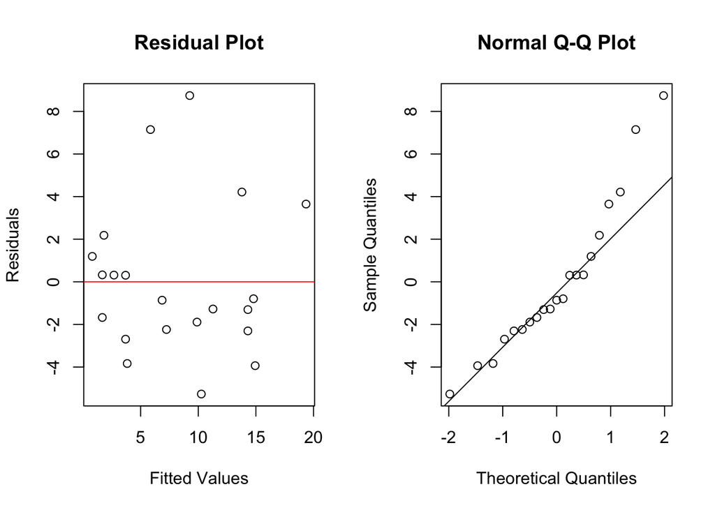

```r
par(mfrow=c(1,2))
#Equal Variances
plot(model.2$residuals~model.2$fitted.values,
xlab="Fitted Values", ylab="Residuals",
main="Residual Plot")
abline (h=0, col="red")
##Normality
qqnorm(model.2$residuals)
qqline(model.2$residuals)
```

```r
par (mfrow=c(1,1))
```

# Assumptions look good

1(e)

```r
#Compute Unadjusted Treatment Means
tapply(data1$pre,data1$drug, mean)
```

```
##        A        B        C
## 10.42857 10.28571 14.00000
```

```r
#Find y coordinates
tapply(data1$post,data1$drug,mean)
```

```
##         A         B         C
##  6.285714  6.000000 12.285714
```

So I have determined the covariate adjusted means for each treatment at the mean pre score  
and compare these to the unadjusted means.

```r
mean(data1$pre)
```

```
## [1] 11.57143
```

And after adjustment: drug1bar = -4.2396 + 1.0093*mean(pre) = 7.439444 drug2bar = -4.2396-0.1415 + 1.0093*mean(pre) = 7.297944 drug3bar = -4.2396 + 2.3954 + 1.0093*mean(pre)= 9.834844

1(f)

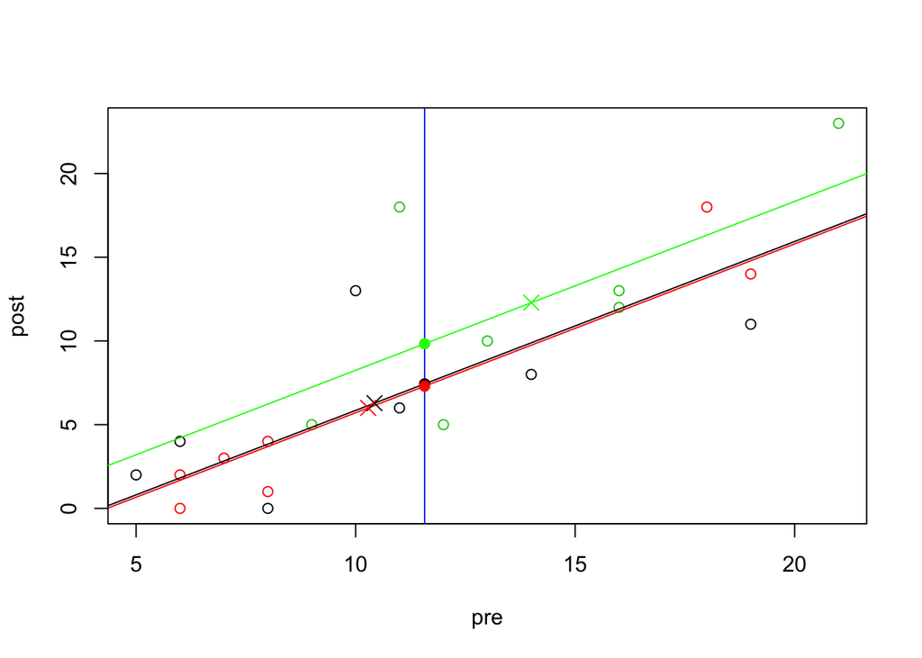

```r
plot(data1$post~data1$pre,col=data1$drug,xlab="pre", ylab="post")
abline (v=mean(data1$pre), col="blue")
abline (a=-4.2396, b=1.0093,, col="black")
abline (a=-4.3811, b=1.0093 , col="red")
abline (a=-1.8442, b=1.0093, col="green")
points(x=mean(data1$pre),y=7.439444,pch=19,col="black")
points(x=mean(data1$pre),y=7.297944,pch=19,col="red")
points(x=mean(data1$pre),y=9.834844,pch=19,col="green")
points(x= 10.42857, y=-4.2396 + 1.0093*10.42857, pch=4, col="black",cex=1.5)
points(x= 10.28571, y=-4.2396-0.1415 + 1.0093*10.28571, pch=4, col="red",cex=1.5)
points(x= 14.00000 ,y=-4.2396 + 2.3954 + 1.0093*14, pch=4,col="green",cex=1.5)
```

Discuss how the plot explains the pvalue for drug from ANOVA and ANCOVA: ANCOVA compares same ovariate. ANOVA, compares different covariate.

2.stem and IQ (a)

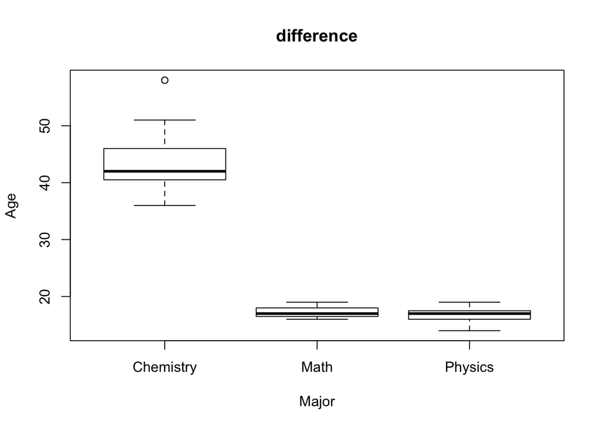

```r
data2 = read.csv("~/downloads/IQ.csv",header = T)
plot(data2$Age ~ data2$Major,xlab="Major", ylab="Age",main="difference")
```

From box plot the age varies from major, so they are relative.

2(b) Age is covariate

```r
# test if major affects covariate
model.2.1 = lm(Age ~ Major,data=data2)
anova(model.2.1)
```

```
## Analysis of Variance Table
##
## Response: Age
##           Df Sum Sq Mean Sq F value    Pr(>F)
## Major      2 7455.6  3727.8  235.94 < 2.2e-16 ***
## Residuals 42  663.6    15.8
## ---
## Signif. codes:  0 '***' 0.001 '**' 0.01 '*' 0.05 '.' 0.1 ' ' 1
```

```r
summary(model.2.1)
```

```
##
## Call:
## lm(formula = Age ~ Major, data = data2)
##
## Residuals:
##     Min      1Q  Median      3Q     Max
## -8.3333 -1.3333 -0.3333  0.6667 13.6667
##
## Coefficients:
##              Estimate Std. Error t value Pr(>|t|)
## (Intercept)    44.333      1.026   43.20   <2e-16 ***
## MajorMath     -27.000      1.451  -18.60   <2e-16 ***
## MajorPhysics  -27.600      1.451  -19.02   <2e-16 ***
## ---
## Signif. codes:  0 '***' 0.001 '**' 0.01 '*' 0.05 '.' 0.1 ' ' 1
##
## Residual standard error: 3.975 on 42 degrees of freedom
## Multiple R-squared:  0.9183, Adjusted R-squared:  0.9144
## F-statistic: 235.9 on 2 and 42 DF,  p-value: < 2.2e-16
```

p-value: < 2.2e-16 which is very small, which means the major affects covariate. The test proves A.

2(c)

```r
res.co= residuals(model.2.1)
model.2.2= lm( IQ~ res.co*Major,data=data2)
anova(model.2.2)
```

```
## Analysis of Variance Table
##
## Response: IQ
##              Df  Sum Sq Mean Sq F value    Pr(>F)
## res.co        1    0.25    0.25  0.0066    0.9359
## Major         2 1529.38  764.69 20.0922 1.005e-06 ***
## res.co:Major  2  119.98   59.99  1.5763    0.2196
## Residuals    39 1484.30   38.06
## ---
## Signif. codes:  0 '***' 0.001 '**' 0.01 '*' 0.05 '.' 0.1 ' ' 1
```

```r
summary(model.2.2)
```

```
##
## Call:
## lm(formula = IQ ~ res.co * Major, data = data2)
##
## Residuals:
##     Min      1Q  Median      3Q     Max
## -15.240  -2.166   0.387   4.235   8.930
##
## Coefficients:
##                     Estimate Std. Error t value Pr(>|t|)
## (Intercept)          48.2000     1.5929  30.260  < 2e-16 ***
## res.co                0.1163     0.2479   0.469   0.6417
## MajorMath           -12.3333     2.2527  -5.475 2.77e-06 ***
## MajorPhysics        -12.4000     2.2527  -5.505 2.52e-06 ***
## res.co:MajorMath     -0.2684     1.5949  -0.168   0.8672
## res.co:MajorPhysics  -2.0794     1.1734  -1.772   0.0842 .
## ---
## Signif. codes:  0 '***' 0.001 '**' 0.01 '*' 0.05 '.' 0.1 ' ' 1
##
## Residual standard error: 6.169 on 39 degrees of freedom
## Multiple R-squared:  0.5264, Adjusted R-squared:  0.4657
## F-statistic: 8.669 on 5 and 39 DF,  p-value: 1.358e-05
```

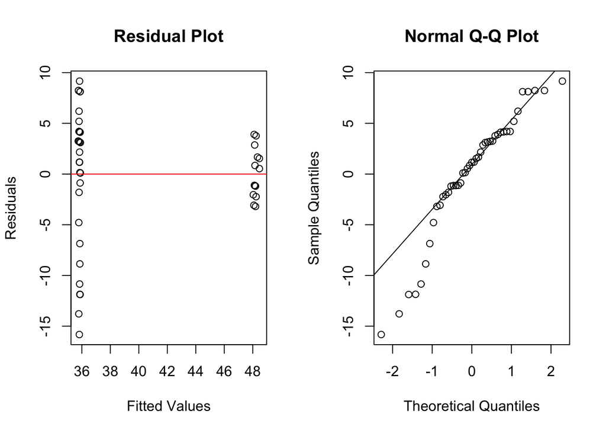

```r
#parallel lines
model.2.3 = lm(IQ ~ res.co+Major,data=data2)
#check assumption
par(mfrow=c(1,2))
plot(model.2.3$residuals ~ model.2.3$fitted.values,xlab="Fitted Values",ylab="Residuals",main="Residual Plot")
abline (h=0, col="red")
qqnorm(model.2.3$residuals)
qqline(model.2.3$residuals)
```

```r
par(mfrow=c(1,1))
```

To assess model assumptions, we have a look at QQ Plot for normality and residual vs fitted values plot for equal variance assumptions. The points on QQ Plot appear to be not close to the straight line except one point of bottom left corner, we would say normality assumption is not satisfied. The residual vs fitted values plot does not satisfied.

Assumptions failed. TRansformation then:

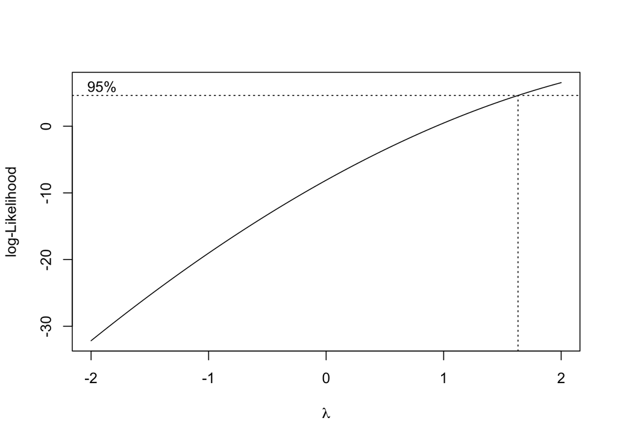

```r
library(MASS)
box=boxcox(model.2.2)
```

```r
lamda= box$x[which.max(box$y)]
lamda
```

```
## [1] 2
```

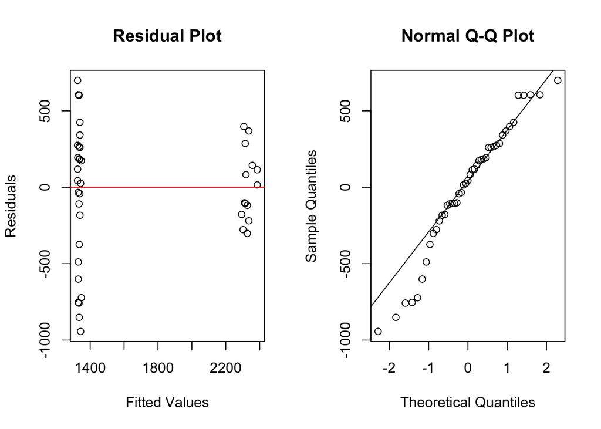

```r
model.2.4=lm(IQ^2 ~ res.co + Major,data=data2)
par(mfrow=c(1,2))
plot(model.2.4$residuals~model.2.4$fitted.values,xlab="Fitted Values",ylab="Residuals",main="Residual Plot")
abline(h=0, col="red")
qqnorm(model.2.4$residuals)
qqline(model.2.4$residuals)
```

```r
par(mfrow=c(1,1))
```

```r
anova(model.2.4)
```

```
## Analysis of Variance Table
##
## Response: IQ^2
##           Df  Sum Sq Mean Sq F value    Pr(>F)
## res.co     1   11576   11576  0.0637    0.8021
## Major      2 9876089 4938045 27.1523 3.092e-08 ***
## Residuals 41 7456464  181865
## ---
## Signif. codes:  0 '***' 0.001 '**' 0.01 '*' 0.05 '.' 0.1 ' ' 1
```

```r
summary(model.2.4)
```

```
##
## Call:
## lm(formula = IQ^2 ~ res.co + Major, data = data2)
##
## Residuals:
##     Min      1Q  Median      3Q     Max
## -943.62 -183.45   43.24  265.88  699.24
##
## Coefficients:
##              Estimate Std. Error t value Pr(>|t|)
## (Intercept)  2328.600    110.111  21.148  < 2e-16 ***
## res.co          4.177     16.555   0.252    0.802
## MajorMath    -997.267    155.720  -6.404 1.15e-07 ***
## MajorPhysics -990.267    155.720  -6.359 1.33e-07 ***
## ---
## Signif. codes:  0 '***' 0.001 '**' 0.01 '*' 0.05 '.' 0.1 ' ' 1
##
## Residual standard error: 426.5 on 41 degrees of freedom
## Multiple R-squared:  0.5701, Adjusted R-squared:  0.5386
## F-statistic: 18.12 on 3 and 41 DF,  p-value: 1.219e-07
```

We can tell basic information form tables above, like intercept or pvalues etc.

3(a)

```r
data3=read.table("http://www.stat.umn.edu/~gary/book/fcdae.data/pr17.1",header=TRUE)
data3$pesticide=as.factor(data3$pesticide)
model.3.0=lm(diameter~pesticide,data=data3)
anova(model.3.0)
```

```
## Analysis of Variance Table
##
## Response: diameter
##           Df  Sum Sq  Mean Sq F value Pr(>F)
## pesticide  3 0.23653 0.078845  1.8461 0.1618
## Residuals 28 1.19586 0.042709
```

```r
#The drug does not affect the covariate
#So we move on to testing the treatment by covariate interaction
model.3.1=lm(calcium.conc~diameter*pesticide,data=data3)
anova(model.3.1)
```

```
## Analysis of Variance Table
##
## Response: calcium.conc
##                    Df  Sum Sq Mean Sq   F value    Pr(>F)
## diameter            1 27.4107 27.4107 3315.6376 < 2.2e-16 ***
## pesticide           3  2.0168  0.6723   81.3178 1.029e-12 ***
## diameter:pesticide  3  0.1255  0.0418    5.0587  0.007413 **
## Residuals          24  0.1984  0.0083
## ---
## Signif. codes:  0 '***' 0.001 '**' 0.01 '*' 0.05 '.' 0.1 ' ' 1
```

Because p is very small so we use seperate lines insted of parallel.

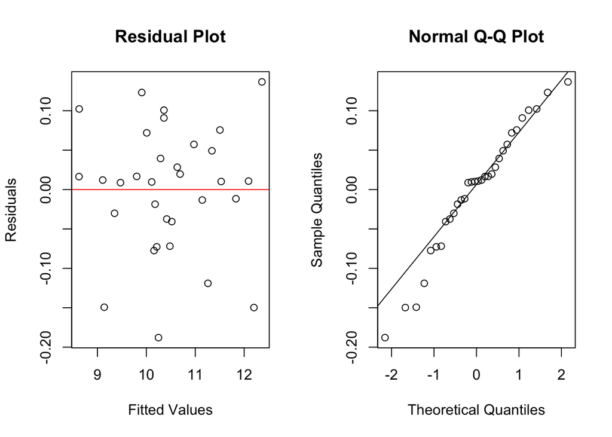

```r
par(mfrow=c(1,2))
plot(model.3.1$residuals ~ model.3.1$fitted.values,xlab="Fitted Values", ylab="Residuals",main="Residual Plot")
abline (h=0, col="red")
qqnorm(model.3.1$residuals)
qqline(model.3.1$residuals)
```

```r
par(mfrow=c(1,1))
summary(model.3.1)
```

```
##
## Call:
## lm(formula = calcium.conc ~ diameter * pesticide, data = data3)
##
## Residuals:
##      Min       1Q   Median       3Q      Max
## -0.18791 -0.03824  0.01049  0.05121  0.13663
##
## Coefficients:
##                     Estimate Std. Error t value Pr(>|t|)
## (Intercept)          0.33804    0.52384   0.645   0.5248
## diameter             4.09025    0.19302  21.190   <2e-16 ***
## pesticide2           1.17449    0.67692   1.735   0.0956 .
## pesticide3          -1.00515    0.67558  -1.488   0.1498
## pesticide4          -0.47351    0.64229  -0.737   0.4681
## diameter:pesticide2 -0.67841    0.25291  -2.682   0.0130 *
## diameter:pesticide3  0.17343    0.25599   0.677   0.5046
## diameter:pesticide4 -0.05382    0.24389  -0.221   0.8272
## ---
## Signif. codes:  0 '***' 0.001 '**' 0.01 '*' 0.05 '.' 0.1 ' ' 1
##
## Residual standard error: 0.09092 on 24 degrees of freedom
## Multiple R-squared:  0.9933, Adjusted R-squared:  0.9914
## F-statistic: 510.7 on 7 and 24 DF,  p-value: < 2.2e-16
```

To assess model assumptions, we have a look at QQ Plot for normality and residual vs fitted values plot for equal variance assumptions. The points on QQ Plot appear to be close to the straight line except one point of bottom left corner, we would say normality assumption is roughly satisfied. The residual vs fitted values plot does not give a clear trend so we conclude that the equal variance assumption is also satisfied.

2(b)

```r
summary(aov(calcium.conc~pesticide,data=data3))
```

```
##             Df Sum Sq Mean Sq F value  Pr(>F)
## pesticide    3  10.86   3.620   5.366 0.00478 **
## Residuals   28  18.89   0.675
## ---
## Signif. codes:  0 '***' 0.001 '**' 0.01 '*' 0.05 '.' 0.1 ' ' 1
```

```r
anova(model.3.1)
```

```
## Analysis of Variance Table
##
## Response: calcium.conc
##                    Df  Sum Sq Mean Sq   F value    Pr(>F)
## diameter            1 27.4107 27.4107 3315.6376 < 2.2e-16 ***
## pesticide           3  2.0168  0.6723   81.3178 1.029e-12 ***
## diameter:pesticide  3  0.1255  0.0418    5.0587  0.007413 **
## Residuals          24  0.1984  0.0083
## ---
## Signif. codes:  0 '***' 0.001 '**' 0.01 '*' 0.05 '.' 0.1 ' ' 1
```

2(C)

```r
bar=tapply(data3$diameter,data3$pesticide,mean)
bar
```

```
##       1       2       3       4
## 2.70875 2.61625 2.53000 2.48375
```

```r
predict(model.3.1,newdata=data.frame(diameter=bar,pesticide=as.factor(c(1,2,3,4))))
```

```
##        1        2        3        4
## 11.41750 10.43875 10.12000  9.89000
```

```r
dia.bar=mean(data3$diameter)
dia.bar
```

```
## [1] 2.584687
```

```r
predict(model.3.1,newdata=data.frame(diameter=dia.bar,pesticide=as.factor(c(1,2,3,4))))
```

```
##        1        2        3        4
## 10.91005 10.33106 10.35317 10.29743
```

```r
#diameter=2.2
predict(model.3.1,newdata=data.frame(diameter=2.2,pesticide=as.factor(c(1,2,3,4))))
```

```
##        1        2        3        4
## 9.336586 9.018572 8.712986 8.744664
```

```r
#diameter=2.8
predict(model.3.1,newdata=data.frame(diameter=2.8,pesticide=as.factor(c(1,2,3,4))))
```

```
##        1        2        3        4
## 11.79074 11.06568 11.27119 11.16652
```

Predict the covariate adjusted means at the mean diameter, diameter=2.2 and 2.8 above.

2(d)

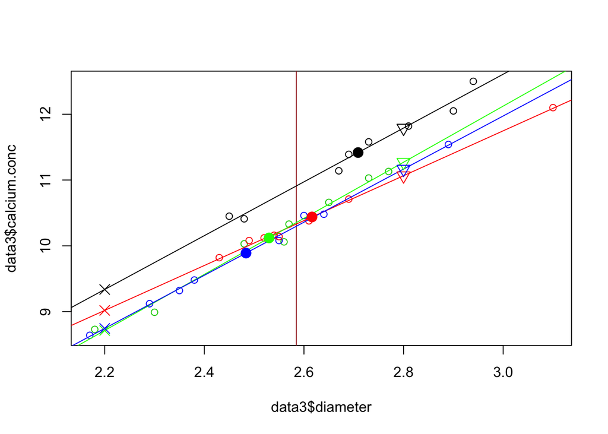

```r
plot(data3$calcium.conc~ data3$diameter,col=as.factor(data3$pesticide))
#mean(data3$diameter)
abline(v=mean(data3$diameter),col="brown")
abline(a=0.33804,b=4.09025,col="black")
abline (a=0.33804 + 1.17449, b=4.09025-0.67841 , col="red")
abline (a=0.33804 - 1.00515, b=4.09025+0.17343, col="green")
abline (a=0.33804 - 0.47351, b=4.09025-0.05382, col="blue")
points(x=bar[1],y=11.41750,col="black",pch=19,cex=1.5)
points(x=bar[2],y=10.43875,col="red",pch=19,cex=1.5)
points(x=bar[3],y=10.12000,col="green",pch=19,cex=1.5)
points(x=bar[4],y=9.89000 ,col="blue",pch=19,cex=1.5)
points(x= 2.2, y = 0.33804 + 4.09025*2.2, pch=4, col="black",cex=1.5)
points(x= 2.2, y = 0.33804 + 1.17449 + (4.09025-0.67841)*2.2, pch=4, col="red",cex=1.5)
points(x= 2.2 ,y = 0.33804 - 1.00515 + (4.09025+0.17343)*2.2, pch=4,col="green",cex=1.5)
points(x= 2.2 ,y = 0.33804 - 0.47351 + (4.09025-0.05382)*2.2, pch=4,col="blue",cex=1.5)
points(x= 2.8, y = 0.33804 + 4.09025*2.8, pch=6, col="black",cex=1.5)
points(x= 2.8, y = 0.33804 + 1.17449 + (4.09025-0.67841)*2.8, pch=6, col="red",cex=1.5)
points(x= 2.8 ,y = 0.33804 - 1.00515 + (4.09025+0.17343)*2.8, pch=6,col="green",cex=1.5)
points(x= 2.8 ,y = 0.33804 - 0.47351 + (4.09025-0.05382)*2.8, pch=6,col="blue",cex=1.5)
```

Plot the data and overlay it with lines from your final model from part a and adjusted means from part c above.

```r
data4 = read.table("http://www.stat.umn.edu/~gary/book/fcdae.data/pr17.5",header=TRUE)
data4$distance=as.factor(data4$distance)

model.4.0=lm(carb.frac ~distance,data=data4)
anova(model.4.0)
```

```
## Analysis of Variance Table
##
## Response: carb.frac
##           Df    Sum Sq    Mean Sq F value Pr(>F)
## distance   1 0.0003503 0.00035030  0.7382 0.4125
## Residuals  9 0.0042710 0.00047455
```

```r
#The distance does not affect the covariate
#So we move on to testing the treatment by covariate interaction
model.4.1=lm(merc.level~carb.frac *distance,data=data4)
anova(model.4.1)
```

```
## Analysis of Variance Table
##
## Response: merc.level
##                    Df    Sum Sq   Mean Sq  F value    Pr(>F)
## carb.frac           1 0.0035679 0.0035679 263.6179 8.184e-07 ***
## distance            1 0.0000218 0.0000218   1.6110    0.2449
## carb.frac:distance  1 0.0000208 0.0000208   1.5387    0.2548
## Residuals           7 0.0000947 0.0000135
## ---
## Signif. codes:  0 '***' 0.001 '**' 0.01 '*' 0.05 '.' 0.1 ' ' 1
```

since interaction’s pvalue is not significant so we use:

```r
model.4.2= lm( merc.level ~ carb.frac + as.factor(soil.type) + as.factor(distance), data= data4)
anova(model.4.2)
```

```
## Analysis of Variance Table
##
## Response: merc.level
##                      Df    Sum Sq   Mean Sq   F value    Pr(>F)
## carb.frac             1 0.0035679 0.0035679 1293.8308 3.334e-09 ***
## as.factor(soil.type)  1 0.0000921 0.0000921   33.3960  0.000678 ***
## as.factor(distance)   1 0.0000260 0.0000260    9.4185  0.018094 *
## Residuals             7 0.0000193 0.0000028
## ---
## Signif. codes:  0 '***' 0.001 '**' 0.01 '*' 0.05 '.' 0.1 ' ' 1
```

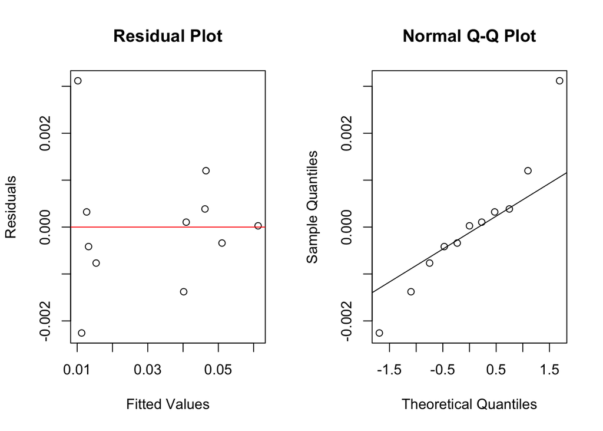

```r
par(mfrow=c(1,2))
plot(model.4.2$residuals ~ model.4.2$fitted.values,xlab="Fitted Values", ylab="Residuals",main="Residual Plot")
abline (h=0, col="red")
qqnorm(model.4.2$residuals)
qqline(model.4.2$residuals)
```

```r
par(mfrow=c(1,1))
summary(model.4.2)
```

```
##
## Call:
## lm(formula = merc.level ~ carb.frac + as.factor(soil.type) +
##     as.factor(distance), data = data4)
##
## Residuals:
##        Min         1Q     Median         3Q        Max
## -2.258e-03 -5.914e-04  2.674e-05  3.541e-04  3.118e-03
##
## Coefficients:
##                         Estimate Std. Error t value Pr(>|t|)
## (Intercept)            0.0081959  0.0009882   8.293 7.24e-05 ***
## carb.frac              0.5975940  0.0568920  10.504 1.55e-05 ***
## as.factor(soil.type)2  0.0138015  0.0023360   5.908 0.000594 ***
## as.factor(distance)2  -0.0032131  0.0010470  -3.069 0.018094 *
## ---
## Signif. codes:  0 '***' 0.001 '**' 0.01 '*' 0.05 '.' 0.1 ' ' 1
##
## Residual standard error: 0.001661 on 7 degrees of freedom
## Multiple R-squared:  0.9948, Adjusted R-squared:  0.9926
## F-statistic: 445.5 on 3 and 7 DF,  p-value: 2.371e-08
```

Because the lm model’s coeffecient is the difference between them, which is -0.0032131 .

4(b)

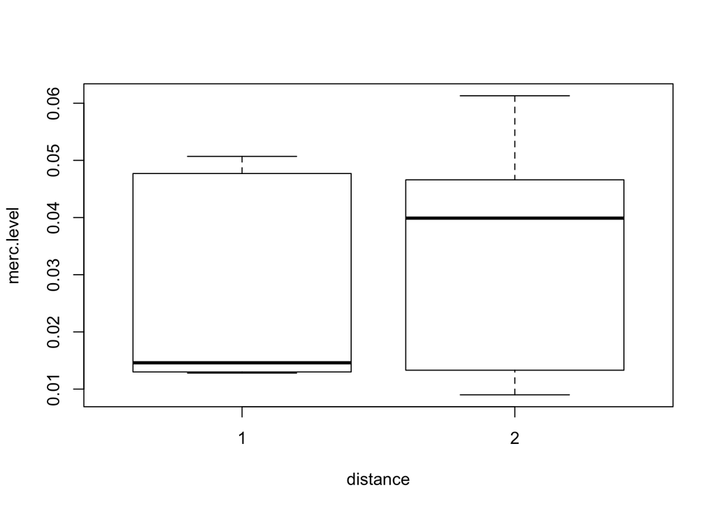

```r
plot(merc.level ~distance,data=data4)
```